# credit-risk-model

Parth Lakdawala

February 20, 2020

Link : [kaggle](https://www.kaggle.com/lakdawalaparth/german-credit-risk-analysis)

- Introduction
  - Dataset Overview
  - Goal of the project
  - Modelling
- Pre-Processing and Feauture selection
  - Selecting variables
  - load libraries
  - Dealing with null values
- Transformation and Inspecting variables
  - Transformation of Job type, Savings.account,Purpose predictors
  - Exploring transformation
  - Transformation of countinous variables and eda
  - Multivariate Transformation and Inspection
  - Checking Multicolinearity
  - Summary and Findings
- Model
  - Introduction of model
  - Fitting logistic Regression Model
  - Analyzing result
    - Interpretation of coefficents
    - Evaluating Model Perfomance
    - Improving Model perfomance by balancing the target variable
- Summary and Conclusion

## 1.Introduction and Context

**Data**: My [dataset](https://www.kaggle.com/uciml/german-credit/kernels) contains information about 1000 german individual and their credit line and loans,including nine different parameters like age, sex, job, housing etc.Each row represent a person who has taken a loan.

**Goal**: By using nine different parameters given in the dataset, we try to indentify riskiness of a loan and classified them into gooad and bad.Here, I am trying to explain how given parameters affecting riskiness of loan.

- Good Loan: It is a good investment from bank perspective and more likely recover the loan.
- Bad Loan: It is a bad investment from bank perpective and less likely to recover the loan, more chances of default.

Thus, it is utmost important to identify a loan correctly, if we identify a good loan as bad loan turns into business loss. on the other hand, if we identify a bad loan as a good loan turns into financial distress.

**Modelling**: I will bulid logistic regression and evaluate the risks associated with other parameters while lending money to a loan applicant. We are trying to optimised result and helping a bank to set the decision parameters in identifying loan is a good or bad investment.

### Important Note:

When I built the model by using the original dataset, the ratio of precision and recall was too law. It means the model was falsely identifying bad loan as a good loan. In business terms, we build the model to maximize profit and to minimize loss. However, here the classification made by the model would increase the risk of bad debt; eventually, it will convert in a financial loss for a bank.

The reason is why model predicting bad loan as a good because the ratio of good loan to the bad loan was 70:30. The values of the good loan were far higher than a bad loan in the target variable because of this reason I found the model was giving biased output and inclined towards the values of a good loan.

To overcome this imbalanced data, I used sampling method which modify the data into balanced distribution. In this analysis, I applied the oversampling method to balance minority class in the target variable.

## 2.Pre-Processing and Feauture selection

#### Selecting variables

Here risk is a dependent variable and other nine variable those are explonatary varible helps us to understand riskiness while lending a loan to customers.

- **Risk**:The variable we are trying to explain called as response variable.
- **Age**:Borrower’s age in years
- **Sex**:Borrower’s sex(male or female)
- **Job**:Types of Job
- **Housing**: Borrower’s housing type
- **Saving accounts**:Type of savings account that shows tendency of borrowers for saving
- **Checking account**:Balance in checking account(Currency:DM - Deutsch Mark)
- **Credit amount**:Credit line used by account holder.
- **Duration**:loan duration in months
- **Purpose**:Purpose of loan

```r
#load data

data <- read.csv("C:/Users/lakda/Desktop/Analytics/Term 2/Data Mining/germanCreditRisk_originalData.csv")
```

```r
#load library
library(ROSE)
library(tidyverse)
library(gridExtra)
library(plyr)
library(knitr)
library(caret)
library(caTools)
library(DMwR)
```

```r
# Checking basic structure and dimension of the dataset

dim(data)
```

```
## [1] 1000   11
```

```r
str(data)
```

```
## 'data.frame':    1000 obs. of  11 variables:
##  $ X               : int  0 1 2 3 4 5 6 7 8 9 ...
##  $ Age             : int  67 22 49 45 53 35 53 35 61 28 ...
##  $ Sex             : Factor w/ 2 levels "female","male": 2 1 2 2 2 2 2 2 2 2 ...
##  $ Job             : int  2 2 1 2 2 1 2 3 1 3 ...
##  $ Housing         : Factor w/ 3 levels "free","own","rent": 2 2 2 1 1 1 2 3 2 2 ...
##  $ Saving.accounts : Factor w/ 4 levels "little","moderate",..: NA 1 1 1 1 NA 3 1 4 1 ...
##  $ Checking.account: Factor w/ 3 levels "little","moderate",..: 1 2 NA 1 1 NA NA 2 NA 2 ...
##  $ Credit.amount   : int  1169 5951 2096 7882 4870 9055 2835 6948 3059 5234 ...
##  $ Duration        : int  6 48 12 42 24 36 24 36 12 30 ...
##  $ Purpose         : Factor w/ 8 levels "business","car",..: 6 6 4 5 2 4 5 2 6 2 ...
##  $ Risk            : Factor w/ 2 levels "bad","good": 2 1 2 2 1 2 2 2 2 1 ...
```

- Some of the variables type need to be transform for better analysis and comparison. First variable **X** is just a serial number, we can get rid of the serial number.

```r
data$X <- NULL
```

```r
#Taking care of missing data

sapply(data, function(x) sum(is.na(x)))
```

```
##              Age              Sex              Job          Housing
##                0                0                0                0
##  Saving.accounts Checking.account    Credit.amount         Duration
##              183              394                0                0
##          Purpose             Risk
##                0                0
```

```r
#Replacing Null Values with mode

data$Saving.accounts[is.na(data$Saving.accounts)]=
  names(table(data$Saving.accounts))[table(data$Saving.accounts)==max(table(data$Saving.accounts))]


data$Checking.account[is.na(data$Checking.account)]=
  names(table(data$Checking.account))[table(data$Checking.account)==max(table(data$Checking.account))]
```

## 3.Transformation and Inspecting variables

#### Transformation of Job type, Savings.account,Purpose predictors

```r
data$Job=as.factor(data$Job)
table(data$Job)
```

```
##
##   0   1   2   3
##  22 200 630 148
```

```r
table(data$Saving.accounts)
```

```
##
##     little   moderate quite rich       rich
##        786        103         63         48
```

```r
table(data$Purpose)
```

```
##
##            business                 car domestic appliances
##                  97                 337                  12
##           education furniture/equipment            radio/TV
##                  59                 181                 280
##             repairs     vacation/others
##                  22                  12
```

```r
#Job Type

data$Job <- mapvalues(data$Job,from =c("0","1","2","3"),
                      to = c("Unskilled","Unskilled","Skilled","Highly Skilled"))

#Type of Savings.account

data$Saving.accounts <- mapvalues(data$Saving.accounts,from =c("little","moderate","quite rich","rich"), to = c("little","moderate","moderate","moderate"))

#Purpose of the loan

data$Purpose <- mapvalues(data$Purpose,from = c("business","car","domestic appliances",
                "education","furniture/equipment","radio/TV","repairs","vacation/others"),
                to = c("business","car","furniture/equipment","education",
                       "furniture/equipment","radio/TV","others","others"))
```

#### Exploring Transformation

```r
g3 <- ggplot(data,aes(x=Job,fill = Job)) +
  geom_bar()+
  ggtitle("Type of Jobs")+
theme_bw()+
      theme(axis.text = element_text(size=12,face = "bold"),
            legend.text = element_text(size = 12),
            axis.title.x = element_blank(),
            axis.title.y = element_blank(),
            panel.grid.major = element_blank(),
            panel.grid.minor = element_blank(),
            panel.border = element_blank(),
            axis.line = element_line(colour = "black")) +
  theme(legend.position="bottom")

table(data$Saving.accounts)
```

```
##
##   little moderate
##      786      214
```

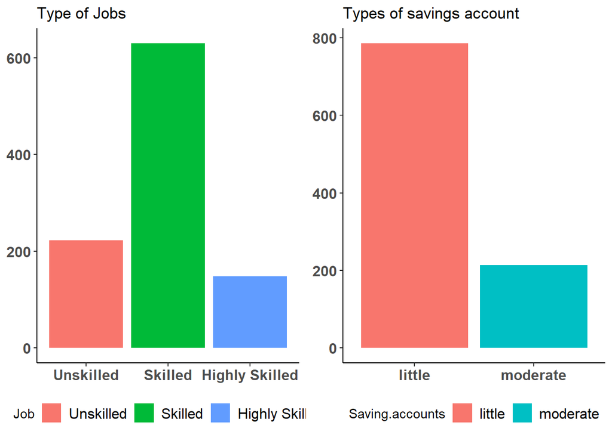

```r
g4 <- ggplot(data,aes(x=Saving.accounts,fill=Saving.accounts))+
  geom_bar()+
  ggtitle("Types of savings account")+
  theme_bw()+
      theme(axis.text = element_text(size=12,face = "bold"),
            legend.text = element_text(size = 12),
            axis.title.x = element_blank(),
            axis.title.y = element_blank(),
            panel.grid.major = element_blank(),
            panel.grid.minor = element_blank(),
            panel.border = element_blank(),
            axis.line = element_line(colour = "black")) +
  theme(legend.position="bottom")

 grid.arrange(g3, g4, nrow=1)
```

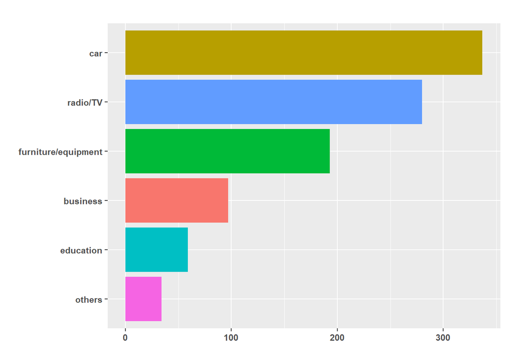

```r
data_filter<- data.frame(table(data$Purpose))
names(data_filter)=c("Purpose","counts")
ggplot(data_filter)+geom_bar(aes(x=reorder(Purpose,+counts),y= counts,fill = Purpose), stat="identity")+ xlab("")+ ylab("")+ ggtitle("")+ theme(legend.position = "none",axis.text = element_text(face = "bold"),plot.title = element_text(colour = "darkorange",face = "bold"))+
  coord_flip()
```

`Job`

`savings.account`

I transformed all the four variable of savings.account to get a more clear understanding of the underlying scenario. Little was more when compared to other three. Hence, I merged other three variable and compared it to little to understand the pattern.

`Purpose of loan`

There were a sparse value in this variable, category repairs and other/vacation was having less amount of example. So, I grouped them into single category named others.

#### Transformation of Countinous Variables and eda

Thare was two countinous variables and I inspect by creating histogram to check skewness in variable.

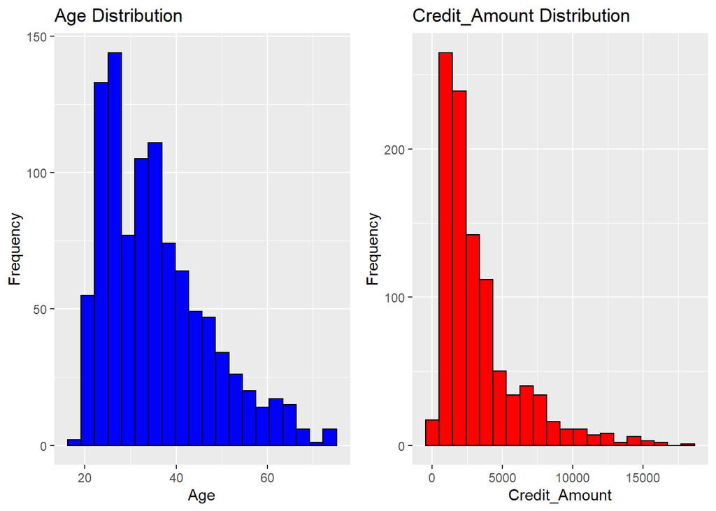

```r
g1 <-  ggplot(data,aes(x = Age)) +
  geom_histogram(bins = 20, fill = 'blue', colour = 'black') +
  ggtitle('Age Distribution') +
  xlab('Age') +
  ylab('Frequency')

g2 <- ggplot(data,aes(x = Credit.amount)) +
  geom_histogram(bins = 20, fill = 'red', colour = 'black') +
  ggtitle('Credit_Amount Distribution') +
  xlab('Credit_Amount') +
  ylab('Frequency')

grid.arrange(g1, g2, nrow=1)
```

- Observation:

We can see both `Age` and `Credit_Amount` are right skewed.So, I used `log1p` function to transform skewness in normal distribution.

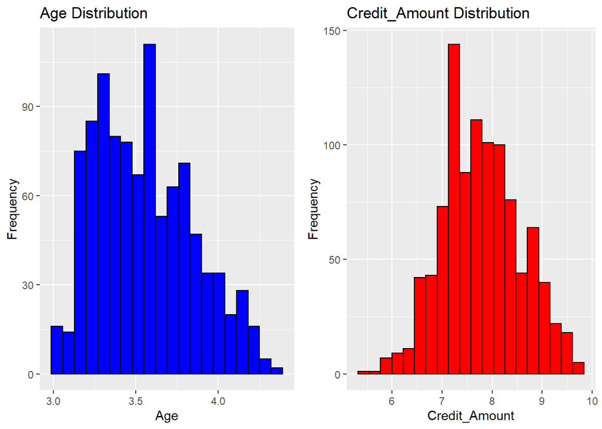

```r
#Transforming variables

g1 <-  ggplot(data,aes(x = log1p(Age))) +
  geom_histogram(bins = 20, fill = 'blue', colour = 'black') +
  ggtitle('Age Distribution') +
  xlab('Age') +
  ylab('Frequency')

g2 <- ggplot(data,aes(x = log1p(Credit.amount))) +
  geom_histogram(bins = 20, fill = 'red', colour = 'black') +
  ggtitle('Credit_Amount Distribution') +
  xlab('Credit_Amount') +
  ylab('Frequency')

grid.arrange(g1, g2, nrow=1)
```

**Age**

Log transformation of age helps to improve our distributon. `Age` variable is still slightly right skew;however it is much better distribution than eralier.

#### Multivariate Transformation and Inspection

##### Dependent ~ Independent relationship

##### Gender vs Credit.Amount

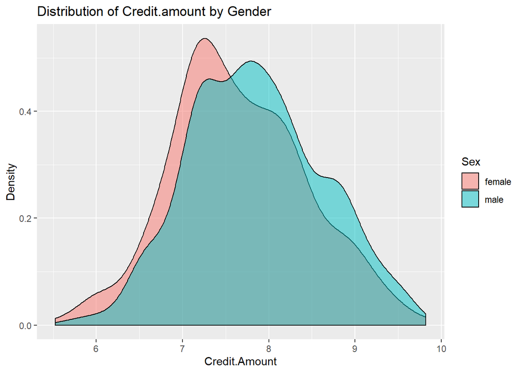

```r
ggplot(data, aes(x=log1p(Credit.amount), fill=Sex)) +
  geom_density(alpha=0.5) +
  ggtitle('Distribution of Credit.amount by Gender') +
  xlab("Credit.Amount") +
  ylab("Density")
```

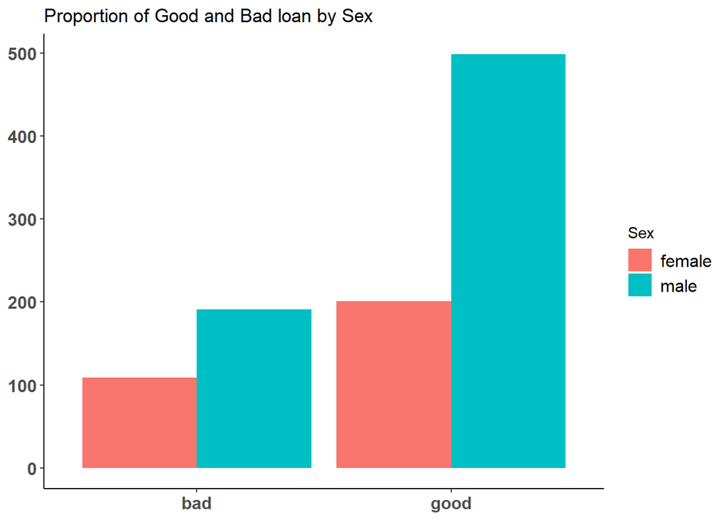

```r
ggplot(data,aes(x=Risk, fill=Sex)) +
  geom_bar(position='dodge') +
  ggtitle("Proportion of Good and Bad loan by Sex")+

      theme_bw()+
      theme(axis.text = element_text(size=12,face = "bold"),
            legend.text = element_text(size = 12),
            axis.title.x = element_blank(),
            axis.title.y = element_blank(),
            panel.grid.major = element_blank(),
            panel.grid.minor = element_blank(),
            panel.border = element_blank(),
            axis.line = element_line(colour = "black"))
```

- Observation
  - The number of male applicant almost double than female.
  - The more risk assosicated with female loan applicant.

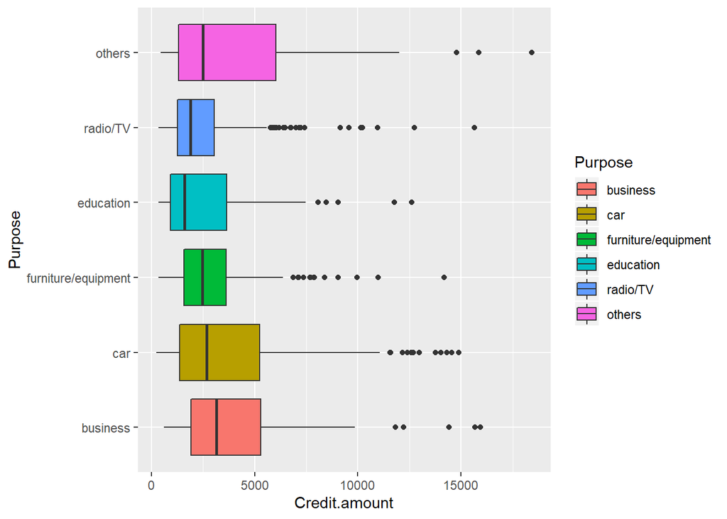

```r
ggplot(data, aes(x=Purpose, y=Credit.amount, fill=Purpose)) +
  geom_boxplot() + coord_flip()
```

- I created age group to inspect more, we can analyze which group applied more for loan and which group carrying more riskiness.

```r
# Categorical age

data <- data %>% mutate(
  AgeCategories = case_when(
    Age >= 18 & Age < 35 ~ 'Young adult',
    Age >= 35 & Age < 60 ~ 'Middle Aged',
    Age >= 60 ~ 'Elderly',
    TRUE ~ as.character(NA)
  )
)
data$AgeCategories %>% table(useNA='always')
```

```
## .
##     Elderly Middle Aged Young adult        <NA>
##          51         401         548           0
```

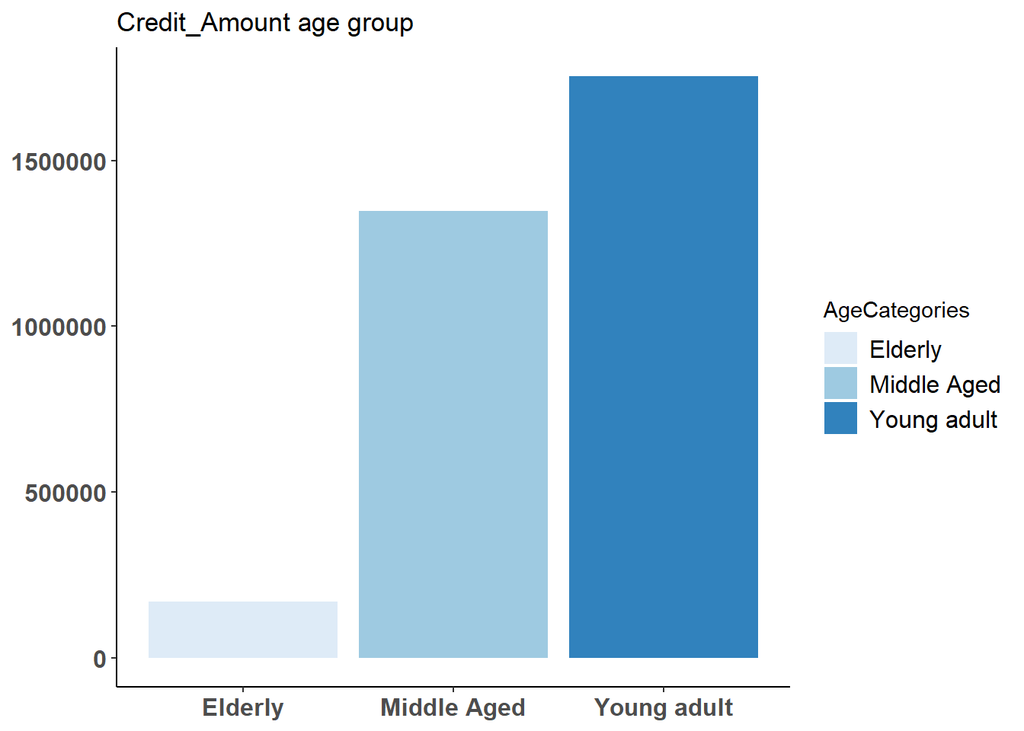

```r
 ggplot(data, aes(x=AgeCategories, y=Credit.amount, fill=AgeCategories)) +
 geom_bar(stat="identity")+
 theme_minimal()+
 scale_fill_brewer(palette="Blues")+
 ggtitle("Credit_Amount age group ")+
 theme(legend.position="none")+
 theme_bw()+
 theme(axis.text = element_text(size=12,face = "bold"),
            legend.text = element_text(size = 12),
            axis.title.x = element_blank(),
            axis.title.y = element_blank(),
            panel.grid.major = element_blank(),
            panel.grid.minor = element_blank(),
            panel.border = element_blank(),
            axis.line = element_line(colour = "black"))
```

- Observation
  - People who fall between age 18 to 35 are applying more for loan will have to inspect the riskiness associated with this group. It is also intresting to know why this group is applying for more credit.

```r
table(data$Housing)
```

```
##
## free  own rent
##  108  713  179
```

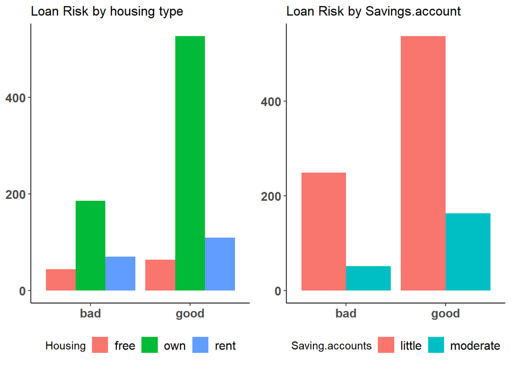

```r
a1 <- ggplot(data,aes(x=Risk, fill=Housing)) +
  geom_bar(position='dodge') +
  ggtitle("Loan Risk by housing type")+

      theme_bw()+
      theme(axis.text = element_text(size=12,face = "bold"),
            legend.text = element_text(size = 12),
            axis.title.x = element_blank(),
            axis.title.y = element_blank(),
            panel.grid.major = element_blank(),
            panel.grid.minor = element_blank(),
            panel.border = element_blank(),
            axis.line = element_line(colour = "black")) +
  theme(legend.position="bottom")


a2<- ggplot(data,aes(x=Risk, fill=Saving.accounts)) +
  geom_bar(position='dodge') +
  ggtitle("Loan Risk by Savings.account")+

      theme_bw()+
      theme(axis.text = element_text(size=12,face = "bold"),
            legend.text = element_text(size = 12),
            axis.title.x = element_blank(),
            axis.title.y = element_blank(),
            panel.grid.major = element_blank(),
            panel.grid.minor = element_blank(),
            panel.border = element_blank(),
            axis.line = element_line(colour = "black")) +
  theme(legend.position="bottom")



grid.arrange(a1,a2,nrow=1)
```

- Observation
  - There is more probabolity of considering loan being risk for people who are having less amount is savings account.
  - The good things about bank most of the client own the house.We can clearly notice that the proportion of people who own the house is significantly higher than other two groups.

#### Checking Correlation between countinous variables(Multicolinearity)

```r
data <- data %>% mutate(LogAge = log(Age),
                    Log1pCredit.amount = log1p(Credit.amount))

print(cor(data$LogAge,data$Log1pCredit.amount))
```

```
## [1] 0.02436977
```

```r
p1 <- ggplot(data,aes(x=LogAge, y=Log1pCredit.amount)) +
  geom_point(colour = "red") +
  geom_smooth(method='lm') +
  ggtitle('Age vs Credit.amount') +
  xlab('Age') +
  ylab('Credit.amount')

print(cor(data$Log1pCredit.amount, data$Duration))
```

```
## [1] 0.6408495
```

```r
p2 <- ggplot(data,aes(x=Log1pCredit.amount, y= Duration)) +
  geom_point(colour = "red") +
  geom_smooth(method='lm') +
  ggtitle('Duration vs Age') +
  xlab('Duartion') +
  ylab('Credit.amount')

print(cor(data$Duration, data$LogAge))
```

```
## [1] -0.02689004
```

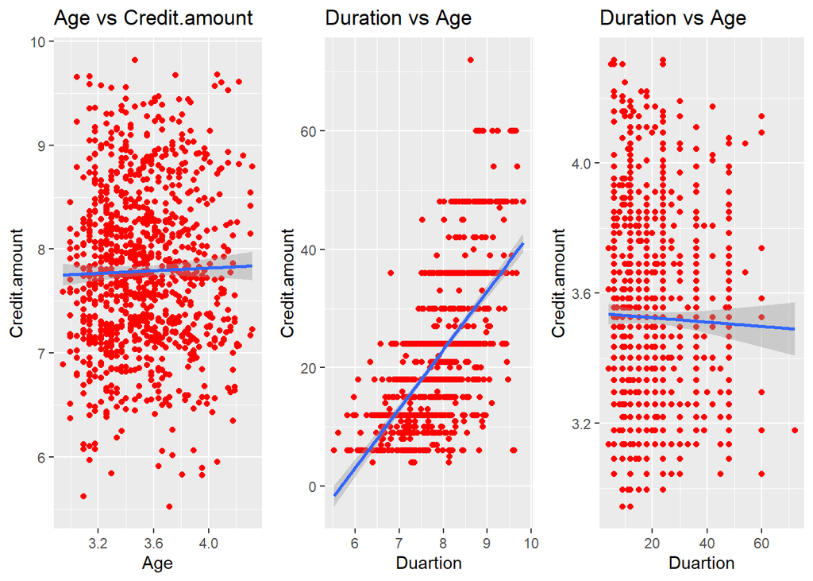

```r
p3 <- ggplot(data,aes(x=Duration, y=LogAge)) +
  geom_point(colour = "red") +
  geom_smooth(method='lm') +
  ggtitle('Duration vs Age') +
  xlab('Duartion') +
  ylab('Credit.amount')

grid.arrange(p1,p2,p3,nrow = 1)
```

## 4.Modeling

I am building a logistic regression model to predict the riskiness of the loan. Many elements in the dataset would help to identify the characteristic of the risk part resides in the loan. The proportion of good credit to the bad loan was 70%, we can say that there 30% chances of the default or it will probably create financial distress for the bank.

I will run baseline model to check how independent variable helping to identify the loan being good or bad. After reading the result of the coefficient of variation, we will decide which variable to keep and which variable to exclude from our analysis.

```r
data$LogAgestd <- scale(data$LogAge)
data$Log1pCredit.amountstd <- scale(data$Log1pCredit.amount)
```

- To make comparison better and accurate, I scaled logged value.Scaling basically normalizing tha data distribute in aparticular range will speep up algoritham perfomance.

#### Fitting Logistic Regression

```r
classifier = glm(formula = Risk ~                  Age+Sex+Job+Housing+Saving.accounts+Checking.account+Duration+Purpose+LogAgestd+Log1pCredit.amountstd,family = binomial,data = data)

summary(classifier)
```

```
##
## Call:
## glm(formula = Risk ~ Age + Sex + Job + Housing + Saving.accounts +
##     Checking.account + Duration + Purpose + LogAgestd + Log1pCredit.amountstd,
##     family = binomial, data = data)
##
## Deviance Residuals:
##     Min       1Q   Median       3Q      Max
## -2.1788  -1.0918   0.6376   0.8296   1.7026
##
## Coefficients:
##                             Estimate Std. Error z value Pr(>|z|)
## (Intercept)                 3.050588   1.510792   2.019  0.04347 *
## Age                        -0.049019   0.039484  -1.241  0.21443
## Sexmale                     0.247506   0.164717   1.503  0.13294
## JobSkilled                  0.080891   0.187523   0.431  0.66620
## JobHighly Skilled          -0.070756   0.258343  -0.274  0.78417
## Housingown                  0.485928   0.247898   1.960  0.04997 *
## Housingrent                 0.050722   0.297225   0.171  0.86450
## Saving.accountsmoderate     0.504438   0.191220   2.638  0.00834 **
## Checking.accountmoderate   -0.513792   0.164568  -3.122  0.00180 **
## Checking.accountrich        0.091865   0.328227   0.280  0.77957
## Duration                   -0.047077   0.008151  -5.776 7.67e-09 ***
## Purposecar                 -0.069518   0.264189  -0.263  0.79245
## Purposefurniture/equipment -0.062254   0.286726  -0.217  0.82812
## Purposeeducation           -0.312144   0.372938  -0.837  0.40260
## Purposeradio/TV             0.492947   0.277196   1.778  0.07535 .
## Purposeothers              -0.198342   0.439468  -0.451  0.65176
## LogAgestd                   0.766685   0.449423   1.706  0.08802 .
## Log1pCredit.amountstd       0.200302   0.102618   1.952  0.05095 .
## ---
## Signif. codes:  0 '***' 0.001 '**' 0.01 '*' 0.05 '.' 0.1 ' ' 1
##
## (Dispersion parameter for binomial family taken to be 1)
##
##     Null deviance: 1221.7  on 999  degrees of freedom
## Residual deviance: 1116.9  on 982  degrees of freedom
## AIC: 1152.9
##
## Number of Fisher Scoring iterations: 4
```

- Observation

There are many variables which did not helping to identify the riskiness in the loan. Simply, we can exclude all those variable which are not significant. We will only keep Savings.account, Checking.account, Duration and Housing as independent variable to predict the riskiness. Before, splitting the dataset into train and test, it would be better to understand the statistical significant of coefficient.

#### Interpreting coefficients

```r
# Exponentiated logistic regression coefficients

classifier %>% coefficients %>% exp %>% round(3)
```

```
##                (Intercept)                        Age
##                     21.128                      0.952
##                    Sexmale                 JobSkilled
##                      1.281                      1.084
##          JobHighly Skilled                 Housingown
##                      0.932                      1.626
##                Housingrent    Saving.accountsmoderate
##                      1.052                      1.656
##   Checking.accountmoderate       Checking.accountrich
##                      0.598                      1.096
##                   Duration                 Purposecar
##                      0.954                      0.933
## Purposefurniture/equipment           Purposeeducation
##                      0.940                      0.732
##            Purposeradio/TV              Purposeothers
##                      1.637                      0.820
##                  LogAgestd      Log1pCredit.amountstd
##                      2.153                      1.222
```

- I run the exponential function to interpret percentage variation of particular predictor in our dataset and how well it contributing in explaining it effects in the model. (I am only explaining those coefficient which looks significant for our model )

`Housing`: Housing variable converted into dummy variable. We can notice from the estimate that the person who owns the house has positive correlation with loan quality. When person owns the house it increase probability of loan being good by 100*(1.62-1)=62%.

```r
cleanData <- read.csv("C:/Users/lakda/Desktop/Analytics/Term 2/Data Mining/cleanData.csv")
```